# Buying a Car

Gareth Robins

4 December 2016

Those who know me best understand that I don’t like cars. It’s not that I don’t appreciate nice cars, or have favourites, it’s that I just don’t have an encyclopeadic knowledge about the things. I see them as transport from one place to another, and not as objects of desire, or entertainment.

The car I have is a piece of crap, a 2003 Ford Mondeo which lives up to its mnemonic of Fix Once Repair Daily. Recently it has become too expensive to take to the mechanics to fix, and I have more important things to do than spend my weekends trying to fix it myself.

The day that Google and Tesla solve the car ownership problem I’ll be signing up.

So, it’s car buuying time. I hate this process even more than owning a car. I now have to spend money and make a large purchase, denting my holiday and house plans, for another hunk of metal to take me to work and back. So I thought I’d try to automate the process a little, and at the best narrow down the choice to my best options.

We have a certain website in NZ that everyone goes it. I shan’t mention it because the script below involves scraping from their site, which they disallow. But hey, I wasn’t logged in so I didn’t agree to those terms :)

Luckily I did have some broad criteria before searching. I needed a 7 person car. This limited the search dramatically, but I narrowed it down to the Toyota Wish for the purpose of explaining my methods.

[figure not shown]

Not exactly an Astin Martin, but it’ll do

## Scraping and Regex

Scraping pages in R is easy, but then you have to navigate the minefield of tags the developer has setup for you. I was lucky in this case, the page had nice class names that I could extract with XPath, and using Regex I could remove all the parts of the listing I’m not interested in, giving me some nice data.

```r
getCarData <- function(page){
  # Parses the website for the page of the search listings
  # extracts title, price, odometer, year, and location for further analysis

  theURL   <- paste0("PASTE THE SECRET URL HERE :)")
  webpage  <- htmlParse(theURL)
  title    <- xpathSApply(webpage, "//*/div[@class='listingTitle']", xmlValue)
  title    <- gsub("[\r\n +\"+]", "", title)
  year     <- sub(".*(\\d+{4}).*$", "\\1", title)
  odometer <- xpathSApply(webpage, "//*/div[@class='rightArrows']", xmlValue)
  location <- odometers[2:length(odometer)]
  location <- location[seq(1, length(location), 3)]
  location <- gsub(",.*$", "", location)
  odometer <- data.frame(odo_data = subset(odometer, grepl("^([1-90-9\\<\\>])",odometer)))
  odometer <- odometer %>%
              separate(odo_data, c('odo1', 'odo2', 'vehicle_type', 'engine', 'gearbox'), sep = ',') %>%
              mutate(odometer = (as.numeric(odo1) * 1000) + as.numeric(gsub("km", "", odo2))) %>%
              select(odometer, vehicle_type, engine, gearbox)

  prices  <- xpathSApply(webpage, "//*/div[@class='listingPrice']", xmlValue)
  prices  <- gsub("[\r\n +\"+]", "", prices)
  prices  <- as.numeric(gsub("[a-zA-Z\\,\\$]", "", prices))
  results <- cbind(titles, years, odometers, prices, locations)

  return(results)

}


loopThroughPages <- function(pages){
  # Just a wrapper to look through n pages and get the dataframe result.

  for (i in 1:pages){
    pageResults <- getCarData(i)

    if(i == 1){
      results <- pageResults
    } else {
      results <- rbind(carData, pageResults)
    }
  }
  return(results)
}

# Only read in if I haven't already saved the results
#  There is a correction to one of the ads, that had a false odometer reading.
if(!file.exists('data/carData.csv')){
  carData <- loopThroughPages(13)
  carData[carData$titles == 'ToyotaWish2004' & carData$odometer == 10500, 'odometer'] <- 105000
  write.table(carData, 'data/carData-wish.csv', sep=';', row.names=F)
} else {
  carData <- read.table("data/carData-wish.csv", sep=';', header=T)

}

head(carData)
```

```
##                                    titles years odometer   vehicle_type
## 1 ToyotaWish7SEATERLOW82KMXMASSPECIAL2005  2005    82500  Station Wagon
## 2    ToyotaWish7seaterfamilycarAlloys2005  2005   141707            Van
## 3               ToyotaWishBLACKCOLOUR2007  2007    92174            Van
## 4        ToyotaWish1.8XPackage7seater2008  2008    56234  Station Wagon
## 5        ToyotaWish***ArrivingSoon***2007  2007    94000            Van
## 6    ToyotaWish7SeatersAeroSports1.8L2008  2008   106000  Station Wagon
##                  engine    gearbox prices  locations
## 1  1800cc petrol engine  automatic   7790   Auckland
## 2  1800cc petrol engine  automatic   5500 Canterbury
## 3  1794cc petrol engine  automatic   7495   Auckland
## 4  1800cc petrol engine  automatic  10749   Auckland
## 5  1800cc petrol engine  automatic   7299   Auckland
## 6  1800cc petrol engine  tiptronic   9500   Auckland
```

Nice clean data :)

## Quick look at the data

Looks good, as I suspected lower odometers and newer years correlate with higher prices, but there is a distribution of prices at each level.

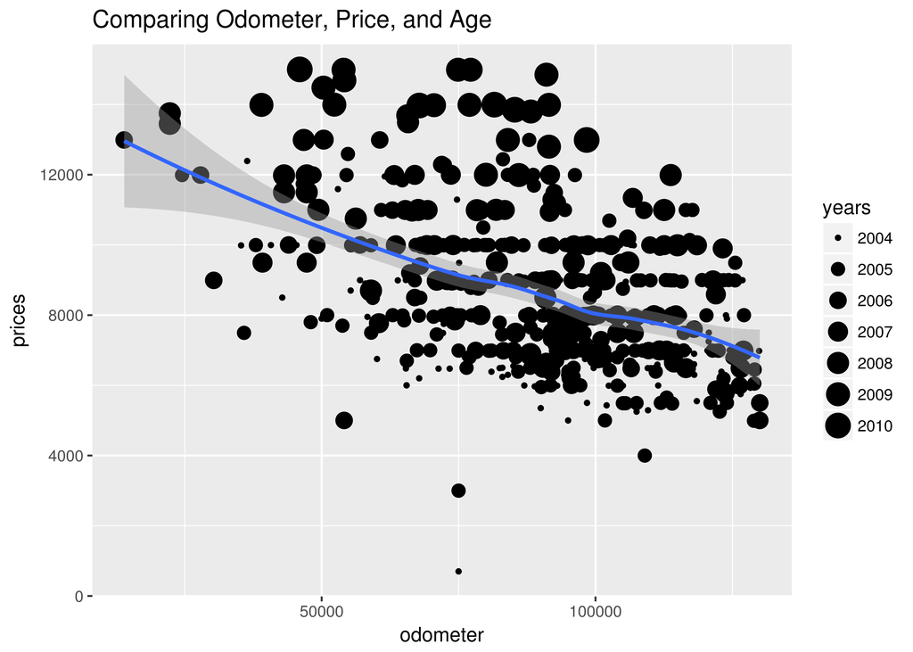

I looked at the model with the most results, and compared prices across locations. I always thought it would be cheaper to buy a car further away from Auckland, but with the exception of Christchurch, Auckland is still cheaper to buy this particular model of the Toyota Wish. I live on the North Shore in Auckland, and that is reflected in the price too!

```
## # A tibble: 30 × 2
##            locations median
##               <fctr>  <dbl>
## 1  Christchurch City   5000
## 2      Auckland City   5500
## 3     Waitakere City   5500
## 4              Taupo   5999
## 5             Timaru   6000
## 6             Nelson   6085
## 7       Manukau City   6645
## 8           Hamilton   6990
## 9             Napier   6995
## 10       North Shore   7000
## # ... with 20 more rows
```

## Monte Carlo

I love this technique for bringing some order to the chaos. Low prices, low odomter, and low age are all important to me. But I’m willing to make sacrifices in one of those metrics if the trade-off is worth it. This is hard to do when browsing online as you are subconsiously being sucked in with the pictures of the cars. In the script below I randomise the weightings I will give to the three metrics, and use these to find the weighted average rank for each vehicle in the dataset.

```r
getWeightedRanks <- function(df, trial){
  weightings    <- runif(3, 1, 100)  # I started with all metrics having same range
  weightings[1] <- runif(1, 1, 40)   # but then realised I valued price > odometer > year
  weightings[2] <- runif(1, 20, 60)
  weightings[3] <- runif(1, 50, 100)
  rankSet <- carData %>%
    filter(prices <= 15000) %>%
    mutate(rankYear = dense_rank(desc(years)),
           rankOdometer = dense_rank(odometer),
           rankPrice = dense_rank(prices)) %>%
    select(titles, odometer, rankYear, rankOdometer, rankPrice)
  df$trialNum <- trial
  df$weightedRank <- rowSums(rankSet[, 2:4] * weightings, na.rm=T) / sum(weightings)
  return(df)
}

runMonteCarlo <- function(trials){
  # Just
  for (i in 1:trials){

    mc_trial_results <- carData %>% filter(prices <= 15000) %>% getWeightedRanks(i)

    if(i == 1){
      Results <- mc_trial_results
    } else {
      Results <- rbind(Results, mc_trial_results)
    }
  }
  return(Results)
}

mcResults <- runMonteCarlo(100)
```

# Distribution

Each line is a listing, and this plot shows the distribution of ranks for each vehicle after all the trials were complete. I’m interested in the listings that show more consistently high rankings, no matter what the weightings are. Those are the listings on the left of the graph and summarised in the table below

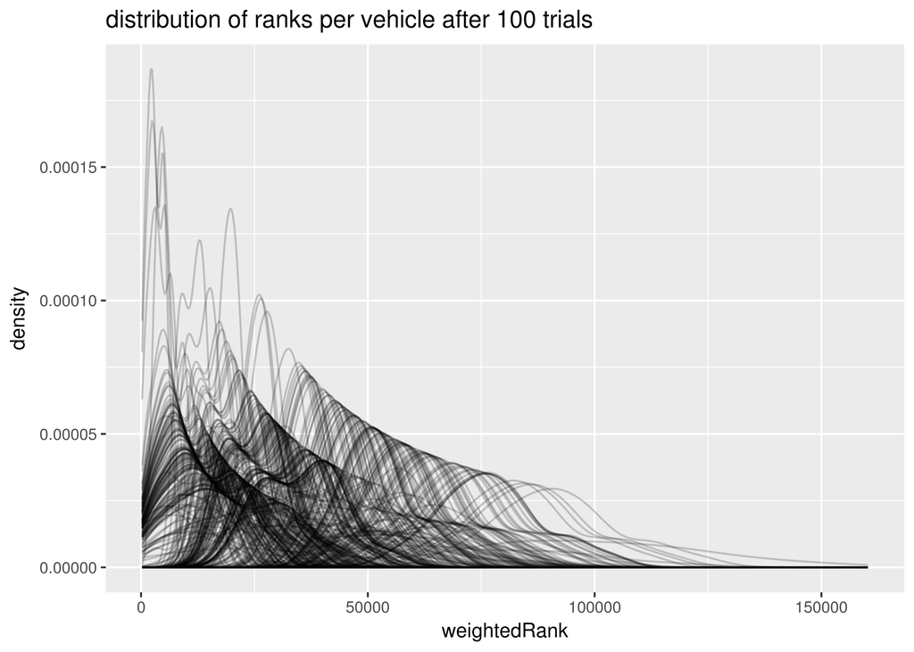

```r
p1 <- mcResults %>%
  filter(odometer > 0) %>%
  ggplot(aes(weightedRank))
p1 + geom_line(aes(group=titles), stat="density", size=0.5, alpha=0.2) +
  ggtitle("distribution of ranks per vehicle after 100 trials")
```

```r
mcResults %>%
  filter(odometer > 0, years >= 2006) %>%
  group_by(titles, odometer, prices, years, locations) %>%
  summarise(medRank = median(weightedRank)) %>%
  arrange(medRank) %>%
  head(20)
```

```
## Source: local data frame [20 x 6]
## Groups: titles, odometer, prices, years [20]
##
##                                          titles odometer prices years
##                                          <fctr>    <int>  <int> <int>
## 1       ToyotaWishX-LTD22,266KMS!REARCAMERA2008    22266  13450  2008
## 2       ToyotaWishX-LTD22,266KMS!REARCAMERA2008    22266  13750  2008
## 3                            ToyotaWish2.0G2006    13930  12990  2006
## 4                               ToyotaWishX2006    30290   8990  2006
## 5      ToyotaWishX43KMS!REVERSINGCAMERA/DVD2008    43128  11499  2008
## 6                             ToyotaWish1.82006    43963   9999  2006
## 7                        ToyotaWish1.8XAERO2008    46730  12990  2008
## 8      ToyotaWishXLEditionLOWKMS!REARCAMERA2008    47271  11500  2008
## 9      ToyotaWishXLEditionLOWKMS!REARCAMERA2008    47271  11980  2008
## 10                            ToyotaWish1.82008    49398  10999  2008
## 11             ToyotaWish1.8XPackage7seater2008    56234  10749  2008
## 12                           ToyotaWish2.0G2006    27880  11990  2006
## 13 ToyotaWish**BlackInterior**TwoDaysspe...2007    60459   7770  2007
## 14                              ToyotaWishX2007    63248  11990  2007
## 15                           ToyotaWish1.8X2007    63550   9990  2007
## 16               ToyotaWishAeroSportPackage2006    66100   9200  2006
## 17                      ToyotaWish*7SEATER*2006    67000   8500  2006
## 18               ToyotaWish1.8XHIDSELECTION2010    67822  13970  2010
## 19                           ToyotaWish1.8X2009    70509  13980  2009
## 20                ToyotaWishAuctionGrade4.52007    70581   9995  2007
## # ... with 2 more variables: locations <fctr>, medRank <dbl>
```

# Conclusion.

Now I have a list of a cars that I know are the best combination of Price, Odometer, and Age. I can select the ones in the Auckland region from this list since they are priced lower, and perhaps will be more willing to negotiate (also, I’m not flying to Christchurch!). I’ll also take a buddy along that knows a lot more about the mechanical bits than I do.

I’d like to extend this to all makes and models, not just the Toyota Wish, then I can find better bargains, because the Wish is priced quite highly.